# 5502 module 02 demonstration program

## File details

This program was written by Steve Simon on 2025-01-23 and is placed in the public domain. You can use this program any way you please.

This program reads fat.csv, a dataset that compares body fat measurements to girth measurements at various body locations. Refer to the [data dictionary](https://github.com/pmean/data/blob/main/files/fat.yaml) for a more detailed description.

```r
library(car)
library(glue)
library(tidyverse)
library(broom)

R.version.string
```

```
[1] "R version 4.5.0 (2025-04-11 ucrt)"
```

```r
Sys.Date()
```

```
[1] "2026-01-27"
```

#### Comment on the code

The car package provides some helpful functions for various regression models. This an acronym for Companion to Applied Regression, referring to the book, An R Companion to Applied Regression by John Fox and Sanord Weisberg. In this particular program, we use the vif function in car to produce variance inflation factors.

## Intermediate files

- fat: original data from fat.csv
- m0: linear regression with just an intercept
- m1: linear regression using abdomen to predict fat_b
- m2: linear regression using chest, abdomen, hip to predict fat_b
- m3: linear regression using all circumference measures to predict fat_b
- m4: linear regression using age to predict fat_b
- m5: linear regression using age to predict abdomen
- m6: linear regression using age and abdomen to predict fat_b
- rsq_table: listing of r-squared values for various models
- r2: applying augment to m2
- r2a: r2 with all columns except .resid removed

# — Part 1

## Read the data

```r
fat <- read_csv(
  file="../data/fat.csv",
  col_names=TRUE,
  col_types="n")
glimpse(fat)
```

```
Rows: 252
Columns: 19
$ case_number <dbl> 1, 2, 3, 4, 5, 6, 7, 8, 9, 10, 11, 12, 13, 14, 15, 16, 17,…
$ fat_b       <dbl> 12.6, 6.9, 24.6, 10.9, 27.8, 20.6, 19.0, 12.8, 5.1, 12.0, …
$ fat_s       <dbl> 12.3, 6.1, 25.3, 10.4, 28.7, 20.9, 19.2, 12.4, 4.1, 11.7, …
$ dens        <dbl> 1.0708, 1.0853, 1.0414, 1.0751, 1.0340, 1.0502, 1.0549, 1.…
$ age         <dbl> 23, 22, 22, 26, 24, 24, 26, 25, 25, 23, 26, 27, 32, 30, 35…
$ wt          <dbl> 154.25, 173.25, 154.00, 184.75, 184.25, 210.25, 181.00, 17…
$ ht          <dbl> 67.75, 72.25, 66.25, 72.25, 71.25, 74.75, 69.75, 72.50, 74…
$ bmi         <dbl> 23.7, 23.4, 24.7, 24.9, 25.6, 26.5, 26.2, 23.6, 24.6, 25.8…
$ ffw         <dbl> 134.9, 161.3, 116.0, 164.7, 133.1, 167.0, 146.6, 153.6, 18…
$ neck        <dbl> 36.2, 38.5, 34.0, 37.4, 34.4, 39.0, 36.4, 37.8, 38.1, 42.1…
$ chest       <dbl> 93.1, 93.6, 95.8, 101.8, 97.3, 104.5, 105.1, 99.6, 100.9, …
$ abdomen     <dbl> 85.2, 83.0, 87.9, 86.4, 100.0, 94.4, 90.7, 88.5, 82.5, 88.…
$ hip         <dbl> 94.5, 98.7, 99.2, 101.2, 101.9, 107.8, 100.3, 97.1, 99.9, …
$ thigh       <dbl> 59.0, 58.7, 59.6, 60.1, 63.2, 66.0, 58.4, 60.0, 62.9, 63.1…
$ knee        <dbl> 37.3, 37.3, 38.9, 37.3, 42.2, 42.0, 38.3, 39.4, 38.3, 41.7…
$ ankle       <dbl> 21.9, 23.4, 24.0, 22.8, 24.0, 25.6, 22.9, 23.2, 23.8, 25.0…
$ biceps      <dbl> 32.0, 30.5, 28.8, 32.4, 32.2, 35.7, 31.9, 30.5, 35.9, 35.6…
$ forearm     <dbl> 27.4, 28.9, 25.2, 29.4, 27.7, 30.6, 27.8, 29.0, 31.1, 30.0…
$ wrist       <dbl> 17.1, 18.2, 16.6, 18.2, 17.7, 18.8, 17.7, 18.8, 18.2, 19.2…
```

#### Comments on the code

There are 19 columns of data, but they are all numeric, so a single “n” for col_types will do the trick.

## Descriptive statistics for fat_b

```r
fat |>
  summarize(
    fat_mean=mean(fat_b),
    fat_sd=sd(fat_b),
    fat_min=min(fat_b),
    fat_max=max(fat_b))
```

```
# A tibble: 1 × 4
  fat_mean fat_sd fat_min fat_max
     <dbl>  <dbl>   <dbl>   <dbl>
1     18.9   7.75       0    45.1
```

#### Comments on the code

Normally you should use the na.rm argument for mean, sd, etc., but the data dictionary says that missing value codes are not needed for this data.

#### Interpretation of the output

The average patient has 19% body fat. The data has a wide range from 0% (check this value!) to 45%.

Note: while additional descriptive statistics should be calculated for all the important independent variables, we will not show them here in the interest of time and space.

## Correlations

```r
fat |>
  select(
    fat_b,
    chest,
    abdomen,
    hip) |>
  cor() |>
  round(2)
```

```
        fat_b chest abdomen  hip
fat_b    1.00  0.70    0.81 0.63
chest    0.70  1.00    0.92 0.83
abdomen  0.81  0.92    1.00 0.87
hip      0.63  0.83    0.87 1.00
```

#### Comments on the code

The [cor](https://stat.ethz.ch/R-manual/R-devel/library/stats/html/cor.html) function was discussed in Biostats-1. It does help to round the correlations aggressively.

#### Interpretation of the output

Not too surprisingly, there are many strong positive correlations. Patients with higher body fat tend to have higher circumferences and a larger circumference measure at one location tends to be associated with larger circumference measures at other locations.

## Scatterplot of chest circumference and body fat

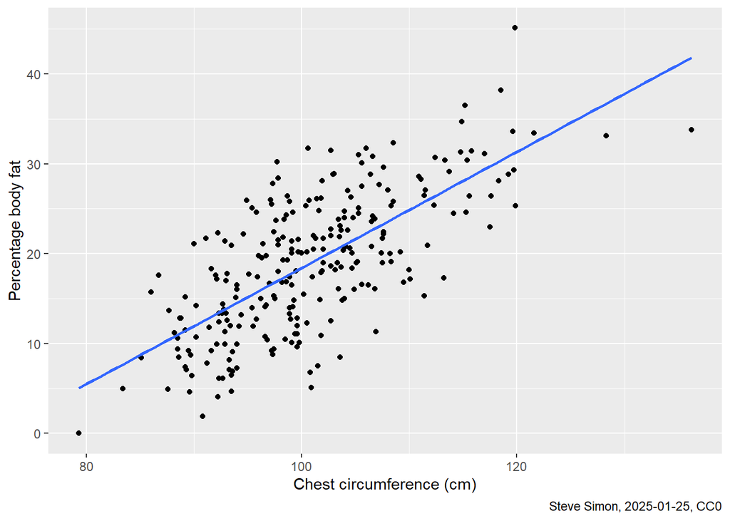

```r
fat |>
  ggplot() +
  aes(x=chest, y=fat_b) +
  geom_point() +
  geom_smooth(method="lm", se=FALSE) +
  labs(
    x="Chest circumference (cm)",
    y="Percentage body fat",
    caption="Steve Simon, 2025-01-25, CC0") -> plot_chest

plot_chest
```

## Scatterplot of abdomen circumference and body fat

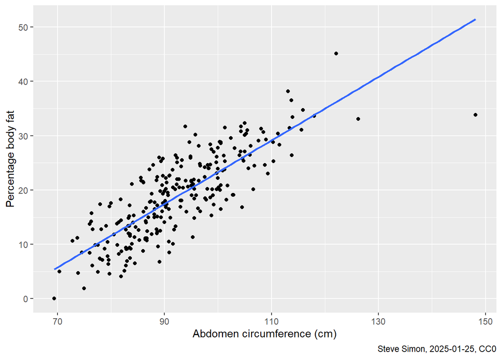

```r
fat |>
  ggplot() +
  aes(x=abdomen, y=fat_b) +
  geom_point() +
  geom_smooth(method="lm", se=FALSE) +
  labs(
    x="Abdomen circumference (cm)",
    y="Percentage body fat",
    caption="Steve Simon, 2025-01-25, CC0") -> plot_abdomen

plot_abdomen
```

#### Interpretation of the output

There is a somewhat stronger positive relationship between abdomen circumference and percentage body fat.

## Scatterplot of hip circumference and body fat

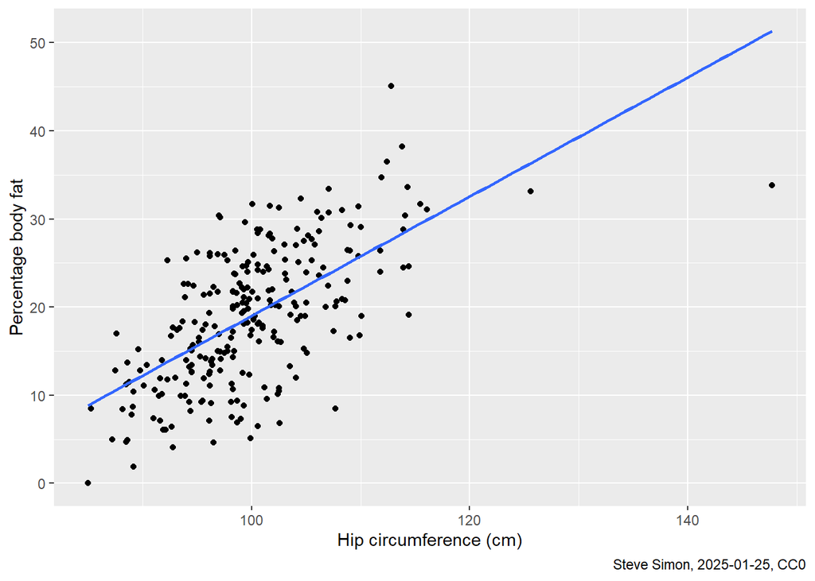

```r
fat |>
  ggplot() +
  aes(x=hip, y=fat_b) +
  geom_point() +
  geom_smooth(method="lm", se=FALSE) +
  labs(
    x="Hip circumference (cm)",
    y="Percentage body fat",
    caption="Steve Simon, 2025-01-25, CC0") -> plot_hip

plot_hip
```

## Linear regression model

```r
m0 <- lm(
  fat_b ~ 1,
  data=fat)

m1 <- lm(
  fat_b ~ abdomen,
  data=fat)

m2 <- lm(
  fat_b ~ chest + abdomen + hip,
  data=fat)

m3 <- lm(
  fat_b ~
    neck +
    chest +
    abdomen +
    hip +
    thigh +
    knee +
    ankle +
    biceps +
    forearm +
    wrist,
  data=fat)
```

#### Comments on the code

Although it is not strictly needed for your data analysis, the first model, m0, is a null model that has no predictor variables other than an intercept. This is represented by the formula fat_b~1.

The m1 model is a simple linear regression model using one predictor variable, abdomen circumference, to predict percentage body fat. This is represented by the formula fat_b~abdomen

The m2 model uses three predictor variables, chest, abdomen, and hip circumferences. It will help us address the question whether measurements above and below the abdomen produce better predictions than using just the abdomen circumference alone. To include multiple predictor variables, list them with plus signs between the variables.

The m3 model uses all ten circumference measurements. This model is perhaps a bit excessive, but provides an interesting model that adds the circumferences at the extremities (neck, arms and legs) to the middle three circumferences.

#### Interpretation of the output

There is a total amount of unexplained variation of roughly 15,000 before any variables are entered into the model.

## Analysis of variance for a one variable model

```r
anova(m0, m1)
```

```
Analysis of Variance Table

Model 1: fat_b ~ 1
Model 2: fat_b ~ abdomen
  Res.Df     RSS Df Sum of Sq     F    Pr(>F)
1    251 15079.0
2    250  5094.9  1    9984.1 489.9 < 2.2e-16 ***
---
Signif. codes:  0 '***' 0.001 '**' 0.01 '*' 0.05 '.' 0.1 ' ' 1
```

#### Comments on the code

The [anova](https://stat.ethz.ch/R-manual/R-devel/library/stats/html/anova.lm.html) function compares the results of two linear regression models using an analysis of variance table.

#### Interpretation of the output

The unexplained variation of the null model, 15,000, can be is reduced to an unexplained variation of 5,000 by a one variable model. The one variable model has explained variation of 10,000.

The F-statistic is large and the p-value is small, indicating that the one variable model provides a statistically significant prediction of the percentage of body fat. You could state equivalently that the one variable model provides a statistically significant reduction in unexplained variation over a null model.

## Analysis of variance for a three variable model

```r
anova(m0, m2)
```

```
Analysis of Variance Table

Model 1: fat_b ~ 1
Model 2: fat_b ~ chest + abdomen + hip
  Res.Df     RSS Df Sum of Sq      F    Pr(>F)
1    251 15079.0
2    248  4530.5  3     10548 192.47 < 2.2e-16 ***
---
Signif. codes:  0 '***' 0.001 '**' 0.01 '*' 0.05 '.' 0.1 ' ' 1
```

#### Interpretation of the output

The unexplained variation of the null model, 15,000, can be is reduced to an unexplained variation of 4,500 by a three variable model. The three variable model has explained variation of 10,500.

The F-statistic is large and the p-value is small, indicating that the three variable model provides a statistically significant prediction of the percentage of body fat. You could state equivalently that the one variable model provides a statistically significant reduction in unexplained variation over a null model.

## Analysis of variance for a ten variable model

```r
anova(m0, m3)
```

```
Analysis of Variance Table

Model 1: fat_b ~ 1
Model 2: fat_b ~ neck + chest + abdomen + hip + thigh + knee + ankle +
    biceps + forearm + wrist
  Res.Df     RSS Df Sum of Sq      F    Pr(>F)
1    251 15079.0
2    241  3994.7 10     11084 66.871 < 2.2e-16 ***
---
Signif. codes:  0 '***' 0.001 '**' 0.01 '*' 0.05 '.' 0.1 ' ' 1
```

#### Interpretation of the output

The unexplained variation of the null model, 15,000, can be reduced to an unexplained variation of 4,000 by a ten variable model. The ten variable model has explained variation of 11,000.

The F-statistic is large and the p-value is small, indicating that the ten variable model provides a statistically significant prediction of the percentage of body fat. You could state equivalently that the ten variable model provides a statistically significant reduction in unexplained variation over a null model.

## Calcuation of r-squared for the one variable model

```r
glance(m1) |>
  select(r.squared, deviance)
```

```
# A tibble: 1 × 2
  r.squared deviance
      <dbl>    <dbl>
1     0.662    5095.
```

#### Comments on the code

The [glance](https://broom.tidymodels.org/reference/glance.lm.html) function (part of the broom library) provides a range of summary measures for a linear regression model as well as many other statistical models.

We keep the R-squared value and the deviance. The deviance is a general name for what is unexplained variation (SSE) in the context of linear regression.

#### Interpretation of the output

A model with abdomen reduces unexplained variation to 5,000 and accounts for 66% of the variation in percentage body fat.

## Calcuation of r-squared for the three variable model

```r
glance(m2) |>
  select(r.squared, deviance)
```

```
# A tibble: 1 × 2
  r.squared deviance
      <dbl>    <dbl>
1     0.700    4531.
```

#### Interpretation of the output

A model with chest, abdomen, and hips reduces unexplained variation only slightly more, down to 4,500. This model accounts for 70% of the variation.

```r
glance(m3) |>
  select(r.squared, deviance)
```

```
# A tibble: 1 × 2
  r.squared deviance
      <dbl>    <dbl>
1     0.735    3995.
```

#### Interpretation of the output

A model with every circumference reduces unexplained variation a tiny bit more, to about 4,000 and accounts for about 74% of the variation.

# — Part 2

## Tests of individual regression coefficients, one variable model

```r
tidy(m1) |>
  mutate(
    p.value =
      case_when(
        p.value <  0.001 ~ "< 0.001",
        p.value >= 0.001 ~ as.character(round(p.value, 3))))
```

```
# A tibble: 2 × 5
  term        estimate std.error statistic p.value
  <chr>          <dbl>     <dbl>     <dbl> <chr>
1 (Intercept)  -35.2      2.46       -14.3 < 0.001
2 abdomen        0.585    0.0264      22.1 < 0.001
```

#### Comments on the code

The [tidy](https://cran.r-project.org/web/packages/broom/vignettes/broom.html) function (part of the broom library), provides a nice summary of the coefficients in various statistical models in R. This includes a standardization across all these statistical models. The tidy function also takes the list that is the result of most statistical models in R and extracts the necessary information into a tibble, which makes it easier for you to manipulate the results.

One big modification that this provides is the ability to simplify the display of p-values. Very small p-values are listed as < 0.001 and the other p-values are rounded to three decimal places.

#### Interpretation of the output

## Tests of individual regression coefficients, three variable model

```r
tidy(m2) |>
  mutate(
    p.value =
      case_when(
        p.value <  0.001 ~ "< 0.001",
        p.value >= 0.001 ~ as.character(round(p.value, 3))))
```

```
# A tibble: 4 × 5
  term        estimate std.error statistic p.value
  <chr>          <dbl>     <dbl>     <dbl> <chr>
1 (Intercept)  -11.9      4.83       -2.47 0.014
2 chest         -0.186    0.0806     -2.30 0.022
3 abdomen        0.930    0.0724     12.8  < 0.001
4 hip           -0.365    0.0784     -4.66 < 0.001
```

#### Interpretation of the output

## Tests of individual regression coefficients, ten variable model

```r
tidy(m3) |>
  mutate(
    p.value =
      case_when(
        p.value <  0.001 ~ "< 0.001",
        p.value >= 0.001 ~ as.character(round(p.value, 3))))
```

```
# A tibble: 11 × 5
   term        estimate std.error statistic p.value
   <chr>          <dbl>     <dbl>     <dbl> <chr>
 1 (Intercept)  7.23       6.21      1.16   0.246
 2 neck        -0.582      0.209    -2.79   0.006
 3 chest       -0.0908     0.0854   -1.06   0.289
 4 abdomen      0.960      0.0716   13.4    < 0.001
 5 hip         -0.391      0.113    -3.47   < 0.001
 6 thigh        0.134      0.125     1.07   0.286
 7 knee        -0.0941     0.212    -0.443  0.658
 8 ankle        0.00422    0.203     0.0208 0.983
 9 biceps       0.111      0.159     0.699  0.485
10 forearm      0.345      0.186     1.86   0.064
11 wrist       -1.35       0.471    -2.87   0.004
```

## Comparison of one and three variable models

```r
anova(m1, m2)
```

```
Analysis of Variance Table

Model 1: fat_b ~ abdomen
Model 2: fat_b ~ chest + abdomen + hip
  Res.Df    RSS Df Sum of Sq      F    Pr(>F)
1    250 5094.9
2    248 4530.5  2    564.39 15.447 4.758e-07 ***
---
Signif. codes:  0 '***' 0.001 '**' 0.01 '*' 0.05 '.' 0.1 ' ' 1
```

#### Comments on the code

You can compare the improvement of complex model over a simple model by including the simple and complex model as arguments in the anova function. You can put them in either order, but the table looks closer to the common format if you place the simple model as the first argument.

#### Interpretation of the output

There is a statistically significant improvement using chest and hip in addition to abdomen (m2 vs m1), and for using all circumference measures over just chest, abdomen, and hip.

## Comparison of three and ten variable models

```r
anova(m2, m3)
```

```
Analysis of Variance Table

Model 1: fat_b ~ chest + abdomen + hip
Model 2: fat_b ~ neck + chest + abdomen + hip + thigh + knee + ankle +
    biceps + forearm + wrist
  Res.Df    RSS Df Sum of Sq      F    Pr(>F)
1    248 4530.5
2    241 3994.7  7     535.8 4.6178 7.233e-05 ***
---
Signif. codes:  0 '***' 0.001 '**' 0.01 '*' 0.05 '.' 0.1 ' ' 1
```

#### Interpretation of the output

There is a statistically significant improvement using all circumference measures over just chest, abdomen, and hip.

# — Part 3

## Residuals

```r
r2 <- augment(m2)
```

## Normal probability plot of the residuals

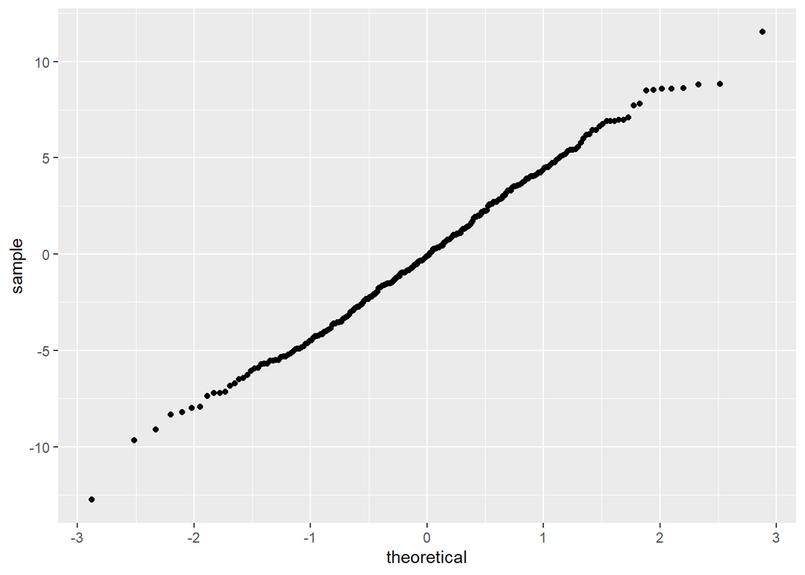

```r
r2 |>
  ggplot() +
  aes(sample=.resid) +
  geom_qq() -> plot_qq

plot_qq
```

#### Comments on the code

The [geom_qq](https://ggplot2.tidyverse.org/reference/geom_qq.html) function produces a normal probability plot. There are several closely related functions that you could also use. See the geom_qq page for details.

#### Interpretation of the output

There are some slight deviations from a linear shape at the extremes, but otherwise, the residuals look like they follow a normal distribution.

## Residual plots versus predicted

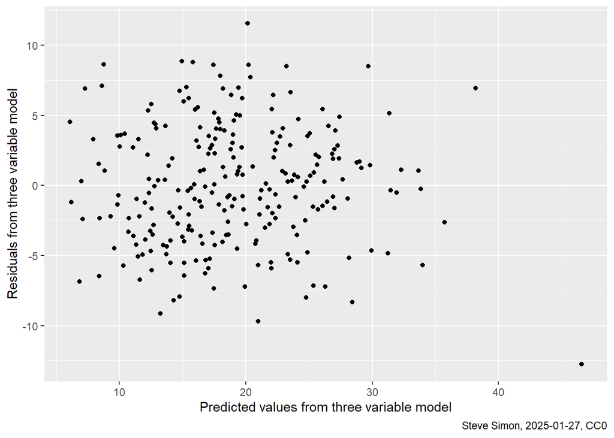

```r
r2 |>
  ggplot() +
  aes(x=.fitted, y=.resid) +
  geom_point() +
  labs(
    x="Predicted values from three variable model",
    y="Residuals from three variable model",
    caption="Steve Simon, 2025-01-27, CC0") -> plot_fitted

plot_fitted
```

#### Interpretation of the output

the plot shows a random featureless pattern, with the exception of one outiler with a very high predicted value and a very large negative residual. The appears to be no evidence of non-linearity or heterogeneity.

## Interpretation of leverage

```r
n <- nrow(fat)
p <- 3

r2 |>
  filter(.hat > 3*(p+1)/n)
```

```
# A tibble: 5 × 10
  fat_b chest abdomen   hip .fitted  .resid   .hat .sigma  .cooksd .std.resid
  <dbl> <dbl>   <dbl> <dbl>   <dbl>   <dbl>  <dbl>  <dbl>    <dbl>      <dbl>
1  33.8  136.   148.   148.    46.6 -12.8   0.205    4.18 0.722        -3.35
2  33.1  128.   126.   126.    35.7  -2.64  0.0574   4.28 0.00616      -0.636
3  30.4  115.   105.    97     29.1   1.25  0.0616   4.28 0.00151       0.303
4  17.2  110.    88.7  102.    12.8   4.37  0.0571   4.27 0.0168        1.05
5  28.1  118.   106.   102.    27.7   0.430 0.0495   4.28 0.000138      0.103
```

#### Interpretation of the output

There are several data points that could be classified as outliers in the independent variable dimensions.

## Display extreme studentized residuals

```r
r2 |>
  filter(abs(.std.resid) > 3)
```

```
# A tibble: 1 × 10
  fat_b chest abdomen   hip .fitted .resid  .hat .sigma .cooksd .std.resid
  <dbl> <dbl>   <dbl> <dbl>   <dbl>  <dbl> <dbl>  <dbl>   <dbl>      <dbl>
1  33.8  136.    148.  148.    46.6  -12.8 0.205   4.18   0.722      -3.35
```

#### Interpretation of the output

There is a single data point with a large studentized residual. It’s one of the points that was also had a high leverage value.

## Display extreme Cook’s distance values

```r
r2 |>
  filter(.cooksd > 1)
```

```
# A tibble: 0 × 10
# ℹ 10 variables: fat_b <dbl>, chest <dbl>, abdomen <dbl>, hip <dbl>,
#   .fitted <dbl>, .resid <dbl>, .hat <dbl>, .sigma <dbl>, .cooksd <dbl>,
#   .std.resid <dbl>
```

#### Interpretation of the output

There are no data points with a large value of Cook’s distance. We still should look carefully at the one point that was a copncern from the perspective of the other two measures.

## Investigate unusual data value

```r
odd_row <- which.max(r2$.std.resid)

r2 |>
  slice_max(abs(.std.resid))
```

```
# A tibble: 1 × 10
  fat_b chest abdomen   hip .fitted .resid  .hat .sigma .cooksd .std.resid
  <dbl> <dbl>   <dbl> <dbl>   <dbl>  <dbl> <dbl>  <dbl>   <dbl>      <dbl>
1  33.8  136.    148.  148.    46.6  -12.8 0.205   4.18   0.722      -3.35
```

#### Comment on the code

The [slice_max](https://dplyr.tidyverse.org/reference/slice.html) function displays the row with the largest value of a particular variable. if there are more than one values tied at the maximum, it displays all of those rows.

## Residual plots versus non-included variables

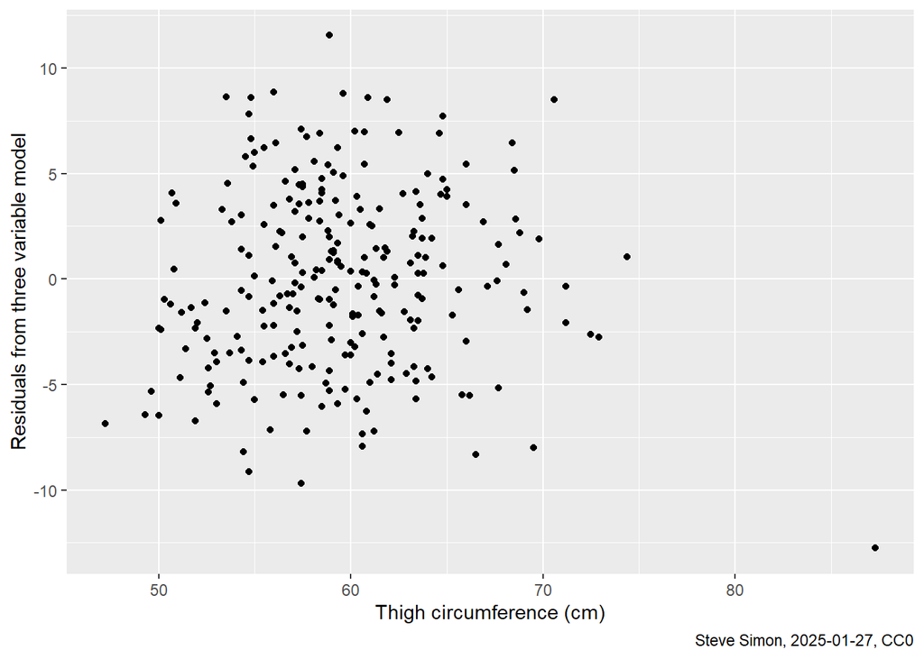

```r
r2 |>
  select(.resid) |>
  bind_cols(fat) -> r2a

r2a |>
  ggplot() +
  aes(x=thigh, y=.resid) +
  geom_point() +
  labs(
    x="Thigh circumference (cm)",
    y="Residuals from three variable model",
    caption="Steve Simon, 2025-01-27, CC0") -> plot_thigh

plot_thigh
```

#### Interpretation of the output

It looks like there is no evidence that the thigh circumference might provide additional predictive power above and beyond the prediction using chest, abdomen, and hip. There is an outlier on the high end for thigh circumference with a large negative residual that may need to be investigated.

I am presenting the remaining plots without interpretation.

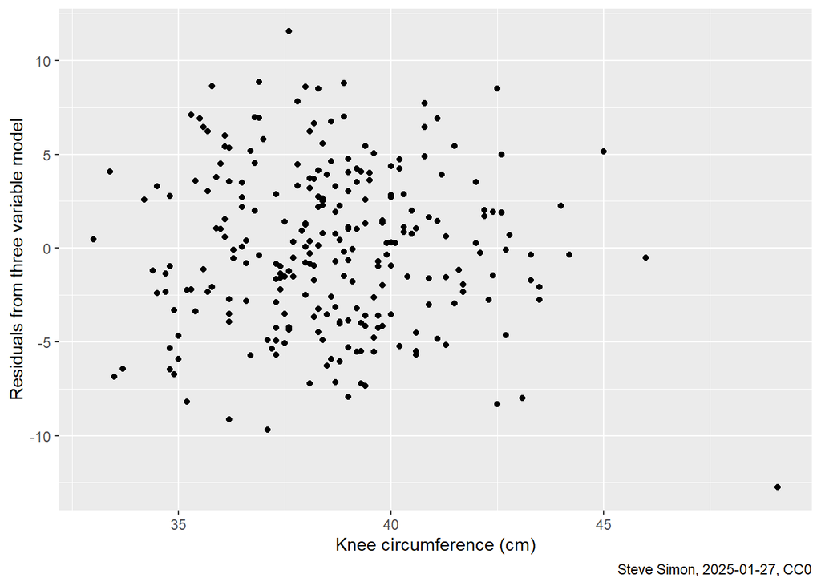

```r
r2a |>
  ggplot() +
  aes(x=knee, y=.resid) +
  geom_point() +
  labs(
    x="Knee circumference (cm)",
    y="Residuals from three variable model",
    caption="Steve Simon, 2025-01-27, CC0")
```

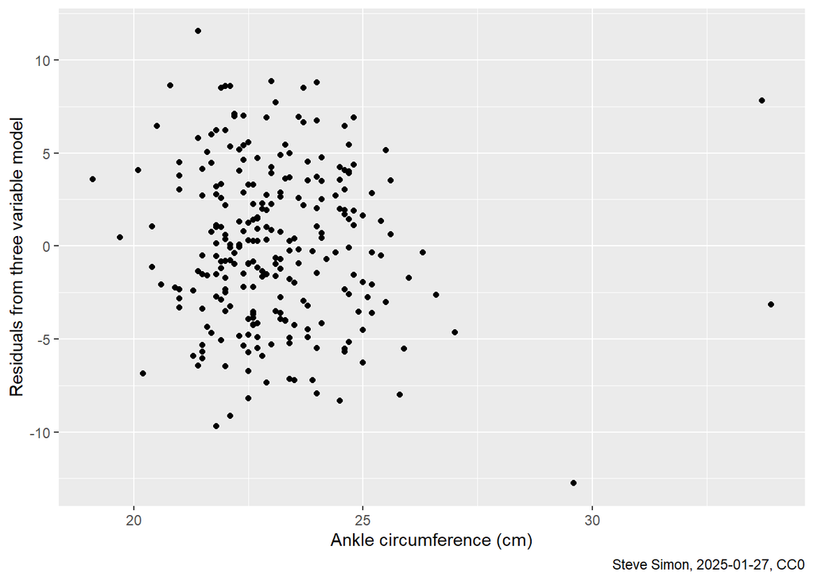

```r
r2a |>
  ggplot() +
  aes(x=ankle, y=.resid) +
  geom_point() +
  labs(
    x="Ankle circumference (cm)",
    y="Residuals from three variable model",
    caption="Steve Simon, 2025-01-27, CC0")
```

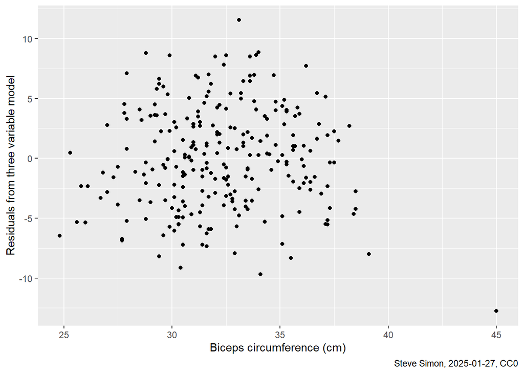

```r
r2a |>
  ggplot() +
  aes(x=biceps, y=.resid) +
  geom_point() +
  labs(
    x="Biceps circumference (cm)",
    y="Residuals from three variable model",
    caption="Steve Simon, 2025-01-27, CC0")
```

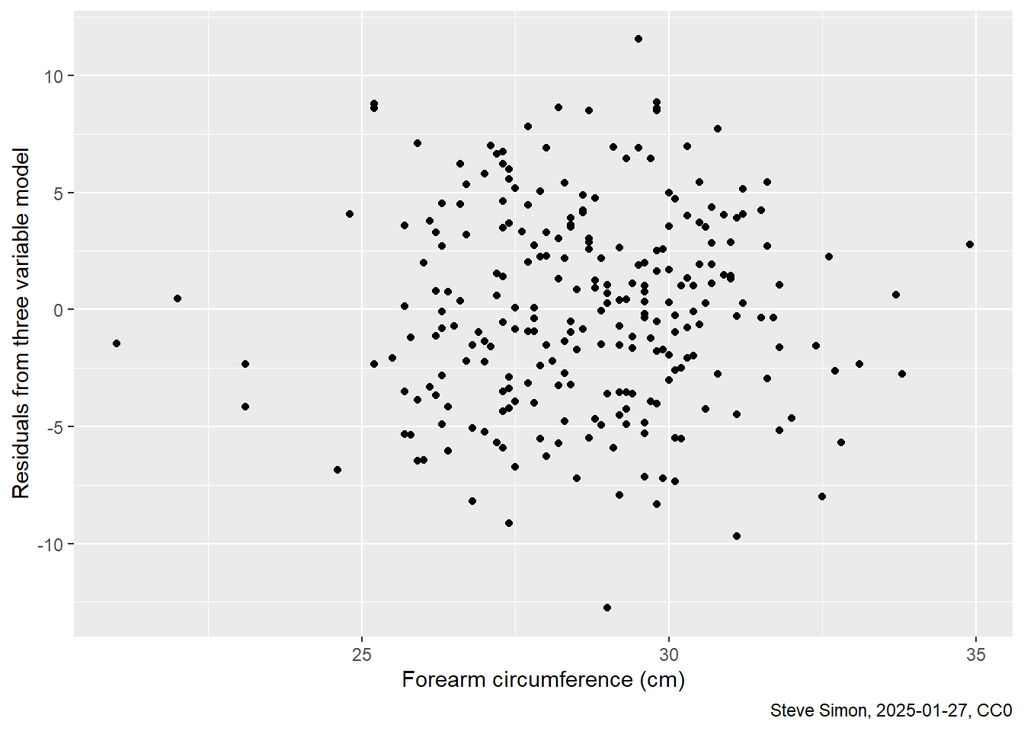

```r
r2a |>
  ggplot() +
  aes(x=forearm, y=.resid) +
  geom_point() +
  labs(
    x="Forearm circumference (cm)",
    y="Residuals from three variable model",
    caption="Steve Simon, 2025-01-27, CC0")
```

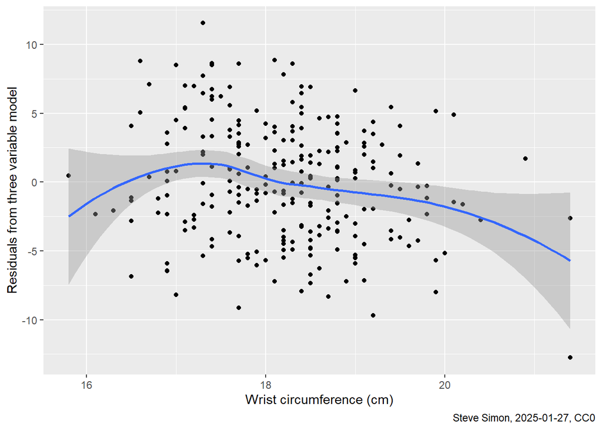

```r
r2a |>
  ggplot() +
  aes(x=wrist, y=.resid) +
  geom_point() +
  geom_smooth(method="loess") +
  labs(
    x="Wrist circumference (cm)",
    y="Residuals from three variable model",
    caption="Steve Simon, 2025-01-27, CC0")
```

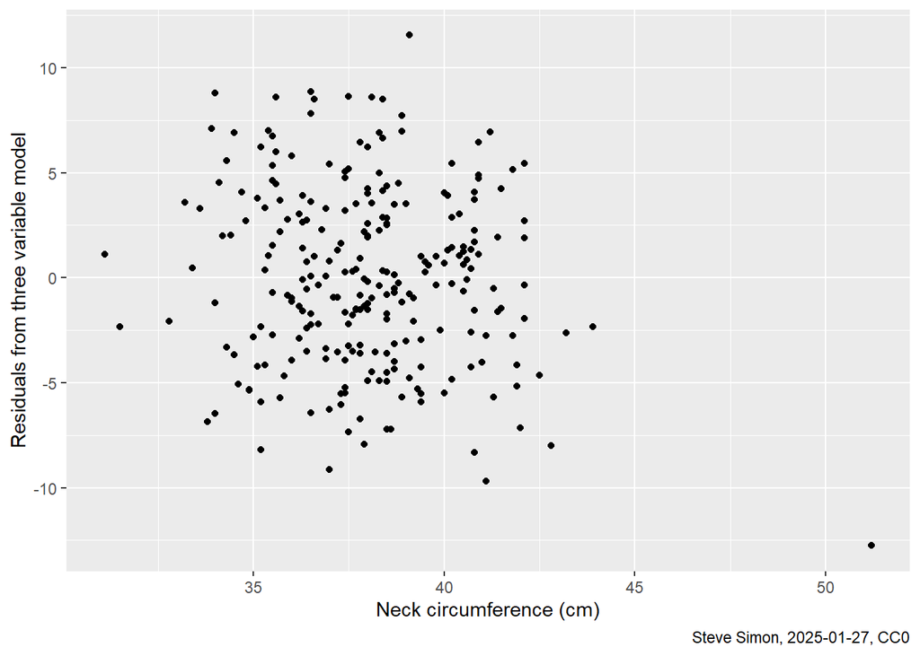

```r
r2a |>
  ggplot() +
  aes(x=neck, y=.resid) +
  geom_point() +
  labs(
    x="Neck circumference (cm)",
    y="Residuals from three variable model",
    caption="Steve Simon, 2025-01-27, CC0")
```

# — Part 4

## Variance inflation factor

```r
library(car)
vif(m2)
```

```
   chest  abdomen      hip
6.340574 8.383840 4.332385
```

# — Part 5

## Linear regression model

```r
m4 <- lm(
    fat_b ~ age,
    data=fat)

m5 <- lm(
    abdomen ~ age,
    data=fat)

m6 <- lm(
    fat_b ~ age + abdomen,
    data=fat)
```

#### Comments on the code

This description comes from a [Bommae Kim webpage](https://library.virginia.edu/data/articles/introduction-to-mediation-analysis) on mediation analysis.

Mediation is tested in three steps. Does the variable influence the outcome, does the variable influence the mediator, and does the effect of the variable on the outcome disappear when you model both the variable and the mediator in predicting the outcome. These results are stored in m4, m5, and m6, respectively.

```r
tidy(m4) |>
  mutate(
    p.value =
      case_when(
        p.value <  0.001 ~ "< 0.001",
        p.value >= 0.001 ~ as.character(round(p.value, 3))))
```

```
# A tibble: 2 × 5
  term        estimate std.error statistic p.value
  <chr>          <dbl>     <dbl>     <dbl> <chr>
1 (Intercept)   11.0      1.74        6.31 < 0.001
2 age            0.178    0.0372      4.78 < 0.001
```

#### Comments on the output

```r
tidy(m5) |>
  mutate(
    p.value =
      case_when(
        p.value <  0.001 ~ "< 0.001",
        p.value >= 0.001 ~ as.character(round(p.value, 3))))
```

```
# A tibble: 2 × 5
  term        estimate std.error statistic p.value
  <chr>          <dbl>     <dbl>     <dbl> <chr>
1 (Intercept)   83.7      2.45       34.1  < 0.001
2 age            0.197    0.0527      3.74 < 0.001
```

#### Comments on the output

```r
tidy(m6) |>
  mutate(
    p.value =
      case_when(
        p.value <  0.001 ~ "< 0.001",
        p.value >= 0.001 ~ as.character(round(p.value, 3))))
```

```
# A tibble: 3 × 5
  term        estimate std.error statistic p.value
  <chr>          <dbl>     <dbl>     <dbl> <chr>
1 (Intercept) -36.5       2.47      -14.8  < 0.001
2 age           0.0660    0.0229      2.88 0.004
3 abdomen       0.567     0.0268     21.2  < 0.001
```

## Save everything

```r
save(
  fat,
  m0,
  m1,
  m2,
  m3,
  m4,
  m5,
  m6,
  rsq_table
  r2,
  plot_chest,
  plot_abdomen,
  plot_hip,
  plot_qq,
  plot_fitted,
  plot_thigh,
  file="../data/module02.RData")
```

```
Error in parse(text = input): <text>:11:3: unexpected symbol
10:   rsq_table
11:   r2
      ^
```